# SF Rent Control Database

Mahal Montes

2025-09-16

## 1. Read in Data

I’m only using two csv files.

1. The first was taken from dataSF after searching their open portal for “Assessor Historical Secured Property Tax Rolls.” This will be our main umbrella data set of housing parcels. https://data.sfgov.org/Housing-and-Buildings/Assessor-Historical-Secured-Property-Tax-Rolls/wv5m-vpq2/about_data
2. The second was taken from the San Francisco Board of Supervisor’s website that included the last amendment to the family plan (7/29/2025). The file was originally a pdf listed under the name “Parcel Tables 081525”. https://sfgov.legistar.com/LegislationDetail.aspx?GUID=0F95C63F-86D3-433A-8B92-069CAB240942&ID=7449404&Options=ID%7CText%7C&Search=250700

## 2. Clean the Data

1. I started by keeping only 12 columns in the Assessor’s big database of parcel data. In the same data frame, I filtered out all the property class codes that obviously are not part of the housing stock.
2. Then, I parsed the height approvals in a table called “lot_table” and also making a parcel number id, which the original data did not contain.

## 3. Create Comprehensive Housing Database

For sanity, I checked the total number of housing properties and units. The numbers match up with dataSF’s latest estimates in the 2023 report. Note that the numbers in the 2023 report are based on 2020 numbers: https://sfplanning.org/sites/default/files/resources/2024-04/2023_Housing_Inventory.pdf?utm.

```
## [1] "Total housing properties in dataset: 190297"
```

```
## [1] "Total housing units in dataset: 431965"
```

Then, I made the rent control database by excluding single family homes, properties built after June 13, 1979, below market rate housing, and other institutional forms of housing like nursing homes, SROs, and government apartments.

```
##            Single Family Built After 1979 Condos  BMR Housing Institutional
## Properties "93824"       "40557"          "56076" " 2472"     "   47"
## Units      "93825"       "76112"          "56076" " 2472"     " 1347"
```

```
##                Status Properties  Units Percentage_Properties Percentage_Units
## 1     Rent Controlled      35862 241384                  18.8             55.9
## 2 Not Rent Controlled     154435 190581                  81.2             44.1
```

## 4. Visualized Rent Control under the Family Zoning Plan

I created an overall summary of rent controlled units and properties that are subject to the rezoning plan. The metrics are counts of units/properties and the percentage of rezoned rent controlled units out of the entire rent control stock.

```
##       Metric Total_RC_Units Eligible_Rezoning Eligible_Housing_Choice
## 1      Units         241384             10015                   33269
## 2 Percentage                             4.1%                   13.8%
```

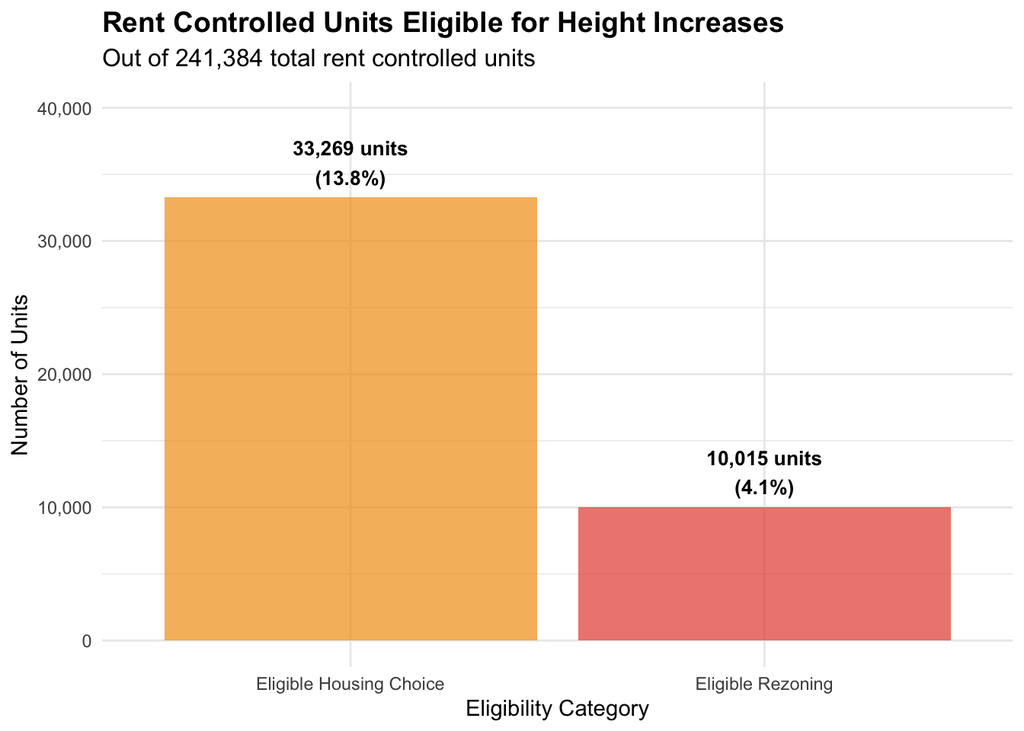

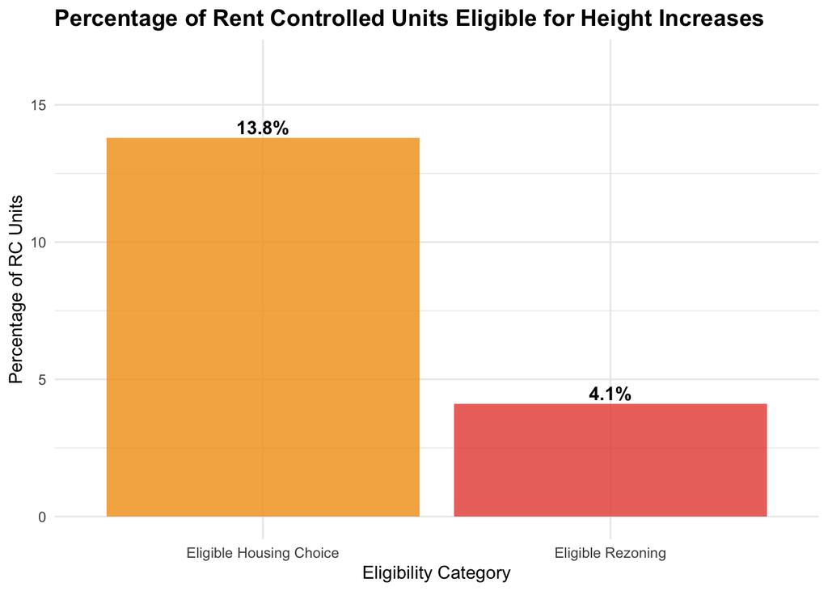

### Extending the Analysis to Supervisor Districts

Voters I spoke to are concerned about changes to their specific district, so this section includes data separated by supervisor district. I calculated the number of rent controlled units that exist in each district in total and the number of units eligible to housing increases under the base rezoning plan as well as the housing choice program height boost.

Then, I explored the percentages rent control (RC) units that are eligible for rezoning.

```
## # A tibble: 11 × 3
##    total_rc_units units_eligible_rezoning units_eligible_housing_choice
##             <int>                   <int>                         <int>
##  1          21974                    2236                          5233
##  2          28629                    2955                          6604
##  3          34647                     719                          3721
##  4           5993                    1519                          2729
##  5          77455                     206                          4531
##  6           4982                     112                           112
##  7          14055                    1466                          2735
##  8          27390                     706                          7488
##  9          16804                       0                            20
## 10           6521                       0                             0
## 11           2869                      96                            96
```

```
## # A tibble: 11 × 2
##    percentage_eligible_rezoning percentage_eligible_housing_choice
##                           <dbl>                              <dbl>
##  1                         10.2                               23.8
##  2                         10.3                               23.1
##  3                          2.1                               10.7
##  4                         25.3                               45.5
##  5                          0.3                                5.8
##  6                          2.2                                2.2
##  7                         10.4                               19.5
##  8                          2.6                               27.3
##  9                          0                                  0.1
## 10                          0                                  0
## 11                          3.3                                3.3
```

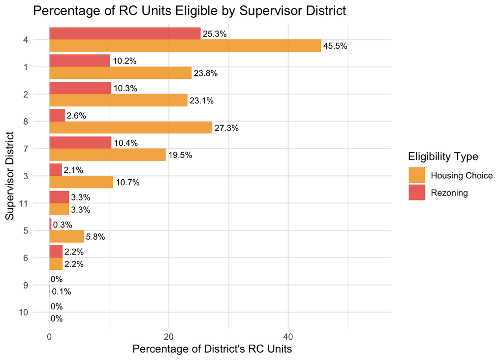

### Rent Control Composition Analysis

```r
# Analyze what percentage of height-eligible properties are rent controlled
height_eligible_composition <- rent_control |>
  summarise(
    # Rezoning eligibility
    total_eligible_rezoning_properties = sum(height_increase_rezoning == TRUE, na.rm = TRUE),
    total_eligible_rezoning_units = sum(Number.of.Units[height_increase_rezoning == TRUE], na.rm = TRUE),
    rc_eligible_rezoning_properties = sum(height_increase_rezoning == TRUE & Rent_controlled == TRUE, na.rm = TRUE),
    rc_eligible_rezoning_units = sum(Number.of.Units[height_increase_rezoning == TRUE & Rent_controlled == TRUE], na.rm = TRUE),

    # Housing Choice eligibility
    total_eligible_housing_choice_properties = sum(height_increase_housing_choice == TRUE, na.rm = TRUE),
    total_eligible_housing_choice_units = sum(Number.of.Units[height_increase_housing_choice == TRUE], na.rm = TRUE),
    rc_eligible_housing_choice_properties = sum(height_increase_housing_choice == TRUE & Rent_controlled == TRUE, na.rm = TRUE),
    rc_eligible_housing_choice_units = sum(Number.of.Units[height_increase_housing_choice == TRUE & Rent_controlled == TRUE], na.rm = TRUE)
  ) |>
  mutate(
    # Calculate percentages
    pct_rc_properties_rezoning = round((rc_eligible_rezoning_properties / total_eligible_rezoning_properties) * 100, 1),
    pct_rc_units_rezoning = round((rc_eligible_rezoning_units / total_eligible_rezoning_units) * 100, 1),
    pct_rc_properties_housing_choice = round((rc_eligible_housing_choice_properties / total_eligible_housing_choice_properties) * 100, 1),
    pct_rc_units_housing_choice = round((rc_eligible_housing_choice_units / total_eligible_housing_choice_units) * 100, 1)
  )

# Create summary table
composition_summary <- data.frame(
  Program = c("Rezoning Plan", "Housing Choice Program"),
  Total_Eligible_Properties = c(height_eligible_composition$total_eligible_rezoning_properties,
                               height_eligible_composition$total_eligible_housing_choice_properties),
  RC_Properties = c(height_eligible_composition$rc_eligible_rezoning_properties,
                   height_eligible_composition$rc_eligible_housing_choice_properties),
  Pct_RC_Properties = c(height_eligible_composition$pct_rc_properties_rezoning,
                       height_eligible_composition$pct_rc_properties_housing_choice),
  Total_Eligible_Units = c(height_eligible_composition$total_eligible_rezoning_units,
                          height_eligible_composition$total_eligible_housing_choice_units),
  RC_Units = c(height_eligible_composition$rc_eligible_rezoning_units,
              height_eligible_composition$rc_eligible_housing_choice_units),
  Pct_RC_Units = c(height_eligible_composition$pct_rc_units_rezoning,
                  height_eligible_composition$pct_rc_units_housing_choice)
)

print("Rent Control Composition Among Height-Eligible Properties:")
```

```
## [1] "Rent Control Composition Among Height-Eligible Properties:"
```

```r
print(composition_summary)
```

```
##                  Program Total_Eligible_Properties RC_Properties
## 1          Rezoning Plan                      4530          1943
## 2 Housing Choice Program                     13903          6817
##   Pct_RC_Properties Total_Eligible_Units RC_Units Pct_RC_Units
## 1              42.9                12988    10015         77.1
## 2              49.0                41434    33269         80.3
```

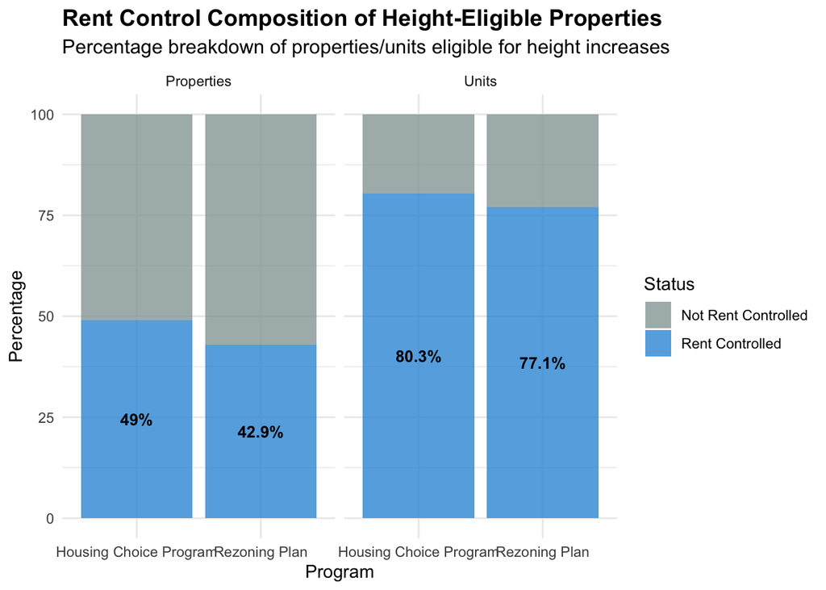

```r
# Create visualization data
composition_viz_data <- data.frame(
  Program = rep(c("Rezoning Plan", "Housing Choice Program"), 2),
  Metric = c(rep("Properties", 2), rep("Units", 2)),
  RC_Percentage = c(height_eligible_composition$pct_rc_properties_rezoning,
                   height_eligible_composition$pct_rc_properties_housing_choice,
                   height_eligible_composition$pct_rc_units_rezoning,
                   height_eligible_composition$pct_rc_units_housing_choice),
  Non_RC_Percentage = c(100 - height_eligible_composition$pct_rc_properties_rezoning,
                       100 - height_eligible_composition$pct_rc_properties_housing_choice,
                       100 - height_eligible_composition$pct_rc_units_rezoning,
                       100 - height_eligible_composition$pct_rc_units_housing_choice)
) |>
  tidyr::gather(key = "Control_Status", value = "Percentage", RC_Percentage, Non_RC_Percentage) |>
  mutate(
    Control_Status = case_when(
      Control_Status == "RC_Percentage" ~ "Rent Controlled",
      Control_Status == "Non_RC_Percentage" ~ "Not Rent Controlled"
    )
  )

# Create stacked bar chart showing rent control composition
composition_plot <- ggplot(composition_viz_data, aes(x = Program, y = Percentage, fill = Control_Status)) +
  geom_bar(stat = "identity", alpha = 0.8) +
  geom_text(aes(label = ifelse(Control_Status == "Rent Controlled",
                              paste0(round(Percentage, 1), "%"), "")),
            position = position_stack(vjust = 0.5), size = 3.5, fontface = "bold") +
  facet_wrap(~Metric, ncol = 2) +
  scale_fill_manual(values = c("Rent Controlled" = "#3498db", "Not Rent Controlled" = "#95a5a6")) +
  labs(title = "Rent Control Composition of Height-Eligible Properties",
       subtitle = "Percentage breakdown of properties/units eligible for height increases",
       x = "Program", y = "Percentage", fill = "Status") +
  theme_minimal() +
  theme(plot.title = element_text(size = 14, face = "bold"),
        plot.subtitle = element_text(size = 12)) +
  scale_y_continuous(limits = c(0, 100))

print(composition_plot)
```

```r
# Rent Control Composition by Supervisor District
district_composition <- rent_control |>
  filter(!is.na(Supervisor.District)) |>
  group_by(Supervisor.District) |>
  summarise(
    # Rezoning eligibility
    total_eligible_rezoning_properties = sum(height_increase_rezoning == TRUE, na.rm = TRUE),
    total_eligible_rezoning_units = sum(Number.of.Units[height_increase_rezoning == TRUE], na.rm = TRUE),
    rc_eligible_rezoning_properties = sum(height_increase_rezoning == TRUE & Rent_controlled == TRUE, na.rm = TRUE),
    rc_eligible_rezoning_units = sum(Number.of.Units[height_increase_rezoning == TRUE & Rent_controlled == TRUE], na.rm = TRUE),

    # Housing Choice eligibility
    total_eligible_housing_choice_properties = sum(height_increase_housing_choice == TRUE, na.rm = TRUE),
    total_eligible_housing_choice_units = sum(Number.of.Units[height_increase_housing_choice == TRUE], na.rm = TRUE),
    rc_eligible_housing_choice_properties = sum(height_increase_housing_choice == TRUE & Rent_controlled == TRUE, na.rm = TRUE),
    rc_eligible_housing_choice_units = sum(Number.of.Units[height_increase_housing_choice == TRUE & Rent_controlled == TRUE], na.rm = TRUE),
    .groups = "drop"
  ) |>
  mutate(
    # Calculate percentages
    pct_rc_properties_rezoning = round((rc_eligible_rezoning_properties / total_eligible_rezoning_properties) * 100, 1),
    pct_rc_units_rezoning = round((rc_eligible_rezoning_units / total_eligible_rezoning_units) * 100, 1),
    pct_rc_properties_housing_choice = round((rc_eligible_housing_choice_properties / total_eligible_housing_choice_properties) * 100, 1),
    pct_rc_units_housing_choice = round((rc_eligible_housing_choice_units / total_eligible_housing_choice_units) * 100, 1)
  ) |>
  # Filter out districts with no eligible properties
  filter(total_eligible_rezoning_properties > 0 | total_eligible_housing_choice_properties > 0)

print("Rent Control Composition by Supervisor District:")
```

```
## [1] "Rent Control Composition by Supervisor District:"
```

```r
print(district_composition)
```

```
## # A tibble: 10 × 13
##    Supervisor.District total_eligible_rezoning_properties total_eligible_rezon…¹
##                  <int>                              <int>                  <int>
##  1                   1                                705                   2552
##  2                   2                                888                   3393
##  3                   3                                 63                    747
##  4                   4                                763                   1908
##  5                   5                                 65                    378
##  6                   6                                 22                    132
##  7                   7                               1656                   2819
##  8                   8                                173                    779
##  9                   9                                  0                      0
## 10                  11                                195                    280
## # ℹ abbreviated name: ¹total_eligible_rezoning_units
## # ℹ 10 more variables: rc_eligible_rezoning_properties <int>,
## #   rc_eligible_rezoning_units <int>,
## #   total_eligible_housing_choice_properties <int>,
## #   total_eligible_housing_choice_units <int>,
## #   rc_eligible_housing_choice_properties <int>,
## #   rc_eligible_housing_choice_units <int>, pct_rc_properties_rezoning <dbl>, …
```

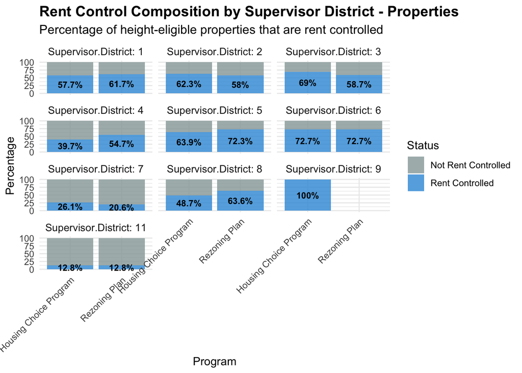

```r
# Create visualization data for districts
district_viz_data <- district_composition |>
  select(Supervisor.District, pct_rc_properties_rezoning, pct_rc_properties_housing_choice,
         pct_rc_units_rezoning, pct_rc_units_housing_choice) |>
  tidyr::gather(key = "Metric_Type", value = "RC_Percentage", -Supervisor.District) |>
  mutate(
    Program = case_when(
      grepl("rezoning", Metric_Type) ~ "Rezoning Plan",
      grepl("housing_choice", Metric_Type) ~ "Housing Choice Program"
    ),
    Metric = case_when(
      grepl("properties", Metric_Type) ~ "Properties",
      grepl("units", Metric_Type) ~ "Units"
    ),
    Non_RC_Percentage = 100 - RC_Percentage
  ) |>
  filter(!is.na(RC_Percentage) & !is.infinite(RC_Percentage)) |>
  tidyr::gather(key = "Control_Status", value = "Percentage", RC_Percentage, Non_RC_Percentage) |>
  mutate(
    Control_Status = case_when(
      Control_Status == "RC_Percentage" ~ "Rent Controlled",
      Control_Status == "Non_RC_Percentage" ~ "Not Rent Controlled"
    )
  )

# Create separate, cleaner plots for properties and units
# Properties plot
properties_viz_data <- district_viz_data |>
  filter(Metric == "Properties")

district_properties_plot <- ggplot(properties_viz_data, aes(x = Program, y = Percentage, fill = Control_Status)) +
  geom_bar(stat = "identity", alpha = 0.8) +
  geom_text(aes(label = ifelse(Control_Status == "Rent Controlled",
                              paste0(round(Percentage, 1), "%"), "")),
            position = position_stack(vjust = 0.5), size = 3, fontface = "bold") +
  facet_wrap(~Supervisor.District, ncol = 3, labeller = label_both) +
  scale_fill_manual(values = c("Rent Controlled" = "#3498db", "Not Rent Controlled" = "#95a5a6")) +
  labs(title = "Rent Control Composition by Supervisor District - Properties",
       subtitle = "Percentage of height-eligible properties that are rent controlled",
       x = "Program", y = "Percentage", fill = "Status") +
  theme_minimal() +
  theme(plot.title = element_text(size = 14, face = "bold"),
        plot.subtitle = element_text(size = 12),
        axis.text.x = element_text(angle = 45, hjust = 1),
        strip.text = element_text(size = 10)) +
  scale_y_continuous(limits = c(0, 100))

print(district_properties_plot)
```

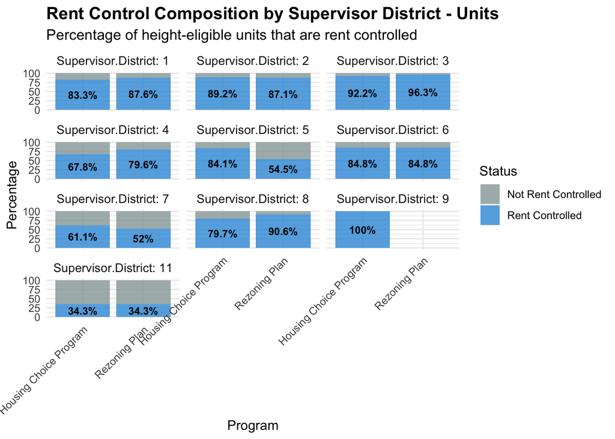

```r
# Units plot
units_viz_data <- district_viz_data |>
  filter(Metric == "Units")

district_units_plot <- ggplot(units_viz_data, aes(x = Program, y = Percentage, fill = Control_Status)) +
  geom_bar(stat = "identity", alpha = 0.8) +
  geom_text(aes(label = ifelse(Control_Status == "Rent Controlled",
                              paste0(round(Percentage, 1), "%"), "")),
            position = position_stack(vjust = 0.5), size = 3, fontface = "bold") +
  facet_wrap(~Supervisor.District, ncol = 3, labeller = label_both) +
  scale_fill_manual(values = c("Rent Controlled" = "#3498db", "Not Rent Controlled" = "#95a5a6")) +
  labs(title = "Rent Control Composition by Supervisor District - Units",
       subtitle = "Percentage of height-eligible units that are rent controlled",
       x = "Program", y = "Percentage", fill = "Status") +
  theme_minimal() +
  theme(plot.title = element_text(size = 14, face = "bold"),
        plot.subtitle = element_text(size = 12),
        axis.text.x = element_text(angle = 45, hjust = 1),
        strip.text = element_text(size = 10)) +
  scale_y_continuous(limits = c(0, 100))

print(district_units_plot)
```

## Analysis by Assessor District

```r
# By Assessor District
by_assessor <- rent_controlled_height_analysis |>
  group_by(Assessor.Neighborhood.District) |>
  summarise(
    total_rc_units = sum(Number.of.Units, na.rm = TRUE),
    units_eligible_rezoning = sum(Number.of.Units[height_increase_rezoning == TRUE], na.rm = TRUE),
    units_eligible_housing_choice = sum(Number.of.Units[height_increase_housing_choice == TRUE], na.rm = TRUE),
    .groups = "drop"
  ) |>
  mutate(
    percentage_eligible_rezoning = round((units_eligible_rezoning / total_rc_units) * 100, 1),
    percentage_eligible_housing_choice = round((units_eligible_housing_choice / total_rc_units) * 100, 1)
  ) |>
  arrange(desc(total_rc_units))

print("Rent Controlled Units Eligible for Height Increases by Assessor District:")
```

```
## [1] "Rent Controlled Units Eligible for Height Increases by Assessor District:"
```

```r
print(by_assessor)
```

```
## # A tibble: 10 × 6
##    Assessor.Neighborhood.District total_rc_units units_eligible_rezoning
##                             <int>          <int>                   <int>
##  1                              6          71995                    1103
##  2                              8          44835                     719
##  3                              5          31457                     617
##  4                              1          23780                    2824
##  5                              9          21661                     112
##  6                              7          20685                    1563
##  7                              2          11792                    2752
##  8                              3           7354                     150
##  9                             10           6213                       3
## 10                              4           1612                     172
## # ℹ 3 more variables: units_eligible_housing_choice <int>,
## #   percentage_eligible_rezoning <dbl>,
## #   percentage_eligible_housing_choice <dbl>
```

```r
# MANOVA analysis for Assessor Districts
# Create data for MANOVA - expand to unit level for proper analysis
assessor_manova_data <- rent_controlled_height_analysis |>
  filter(!is.na(Assessor.Neighborhood.District)) |>
  select(Assessor.Neighborhood.District, height_increase_rezoning, height_increase_housing_choice) |>
  mutate(
    rezoning_eligible = as.numeric(height_increase_rezoning),
    housing_choice_eligible = as.numeric(height_increase_housing_choice)
  )

# Perform MANOVA
assessor_manova <- manova(cbind(rezoning_eligible, housing_choice_eligible) ~ Assessor.Neighborhood.District,
                         data = assessor_manova_data)

print("MANOVA Results for Assessor Districts:")
```

```
## [1] "MANOVA Results for Assessor Districts:"
```

```r
print(summary(assessor_manova))
```

```
##                                   Df   Pillai approx F num Df den Df    Pr(>F)
## Assessor.Neighborhood.District     1 0.034583   338.14      2  18879 < 2.2e-16
## Residuals                      18880
##
## Assessor.Neighborhood.District ***
## Residuals
## ---
## Signif. codes:  0 '***' 0.001 '**' 0.01 '*' 0.05 '.' 0.1 ' ' 1
```

[figure not shown]

```r
# Enhanced Visualization for Assessor Districts with percentages
# Filter to top 10 districts by total units for readability
top_assessor_districts <- by_assessor |>
  slice_max(total_rc_units, n = 10)

assessor_viz_data <- top_assessor_districts |>
  select(Assessor.Neighborhood.District, units_eligible_rezoning, units_eligible_housing_choice,
         percentage_eligible_rezoning, percentage_eligible_housing_choice, total_rc_units) |>
  tidyr::gather(key = "Metric_Type", value = "Value",
                units_eligible_rezoning, units_eligible_housing_choice,
                percentage_eligible_rezoning, percentage_eligible_housing_choice) |>
  mutate(
    Eligibility_Type = case_when(
      grepl("rezoning", Metric_Type) ~ "Rezoning",
      grepl("housing_choice", Metric_Type) ~ "Housing Choice"
    ),
    Data_Type = case_when(
      grepl("units_", Metric_Type) ~ "Units",
      grepl("percentage_", Metric_Type) ~ "Percentage"
    )
  ) |>
  tidyr::spread(key = Data_Type, value = Value)

# Units plot with percentage labels for assessor districts
assessor_units_plot <- ggplot(assessor_viz_data, aes(x = reorder(Assessor.Neighborhood.District, Units),
                                                     y = Units, fill = Eligibility_Type)) +
  geom_bar(stat = "identity", position = "dodge", alpha = 0.8) +
  geom_text(aes(label = paste0(scales::comma(Units), "\n(", round(Percentage, 1), "%)")),
            position = position_dodge(width = 0.9), hjust = -0.1, size = 2.5) +
  coord_flip() +
  labs(title = "Eligible RC Units by Top 10 Assessor Districts",
       subtitle = "Numbers show units (percentage of district's RC units)",
       x = "Assessor District", y = "Number of Units", fill = "Eligibility Type") +
  theme_minimal() +
  scale_fill_manual(values = c("Rezoning" = "#27ae60", "Housing Choice" = "#8e44ad")) +
  scale_y_continuous(labels = scales::comma, expand = expansion(mult = c(0, 0.3))) +
  theme(axis.text.y = element_text(size = 8))

print(assessor_units_plot)
```

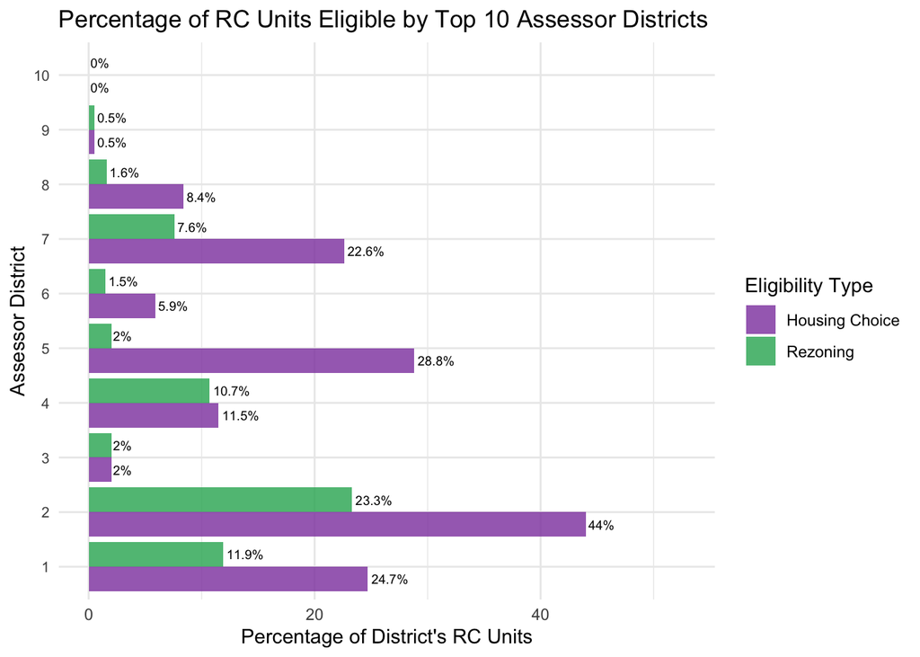

```r
# Percentage comparison plot for assessor districts
assessor_percentage_plot <- ggplot(assessor_viz_data, aes(x = reorder(Assessor.Neighborhood.District, Percentage),
                                                          y = Percentage, fill = Eligibility_Type)) +
  geom_bar(stat = "identity", position = "dodge", alpha = 0.8) +
  geom_text(aes(label = paste0(round(Percentage, 1), "%")),
            position = position_dodge(width = 0.9), hjust = -0.1, size = 2.5) +
  coord_flip() +
  labs(title = "Percentage of RC Units Eligible by Top 10 Assessor Districts",
       x = "Assessor District", y = "Percentage of District's RC Units", fill = "Eligibility Type") +
  theme_minimal() +
  scale_fill_manual(values = c("Rezoning" = "#27ae60", "Housing Choice" = "#8e44ad")) +
  scale_y_continuous(limits = c(0, max(assessor_viz_data$Percentage, na.rm = TRUE) * 1.2)) +
  theme(axis.text.y = element_text(size = 8))

print(assessor_percentage_plot)
```